# Spotify R Analysis

Author

Madeeha Sadiq

## Who are the Arctic Monkeys

Arctic Monkeys are a British rock band from Sheffield, known for their sharp lyrics, dynamic sound, and ever-evolving style. Rising to fame with *Whatever People Say I Am, That’s What I’m Not* in 2006, they became one of the most influential indie rock bands of the 21st century. Their music blends garage rock, post-punk, and psychedelic influences, with albums like *AM* bringing them global stardom. Led by Alex Turner, their ability to reinvent their sound keeps them at the forefront of modern rock. They rose to fame with their Album AM gaining massive popularity with songs like *“Why do you only call me when you’re High” & “R U MINE”.*

# Arctic Monkeys

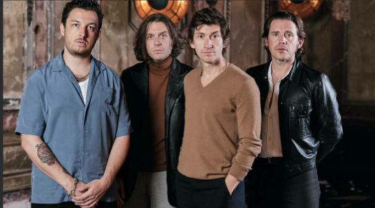

# My Picks

## My Favourite Album

[figure not shown]

### Favourite Worst Nightmare

## Why do you only call me when you’re high!

Youtube link to my favourite song –> [Why do you only call me when you’re high](https://youtu.be/6366dxFf-Os?si=c9eHif8hGYhVoW-w)

### My Favourite Lyrics

“And I can’t see you here wonder where I might?  
Sort of feels like I’m running out of time  
I haven’t found what I was hoping to find  
You said,”You gotta be up in the morning, gonna have an early night  
And you’re starting to bore me, baby  
Why’d you only call me when you’re high?“-

```r
# These are packages I need for the analysis
#options(repos = c(CRAN = "https://cran.rstudio.com/"))
#install.packages("ggplot2")  # Example package
#install.packages("ggplot2")
#install.packages("dplyr")
library(ggplot2)
library(dplyr)
#import data into df

library(readr)

df <- read.csv("Arctic.csv")

#Slice 5 random records into the dataframe
df |> dplyr::slice_sample(n=5) |> knitr::kable(digits = 2)
```

| artist_name | track_name | track_number | album_name | album_release_year | energy | valence | danceability | loudness | speechiness | liveness | tempo | key_mode | duration_ms |
| --- | --- | --- | --- | --- | --- | --- | --- | --- | --- | --- | --- | --- | --- |
| Arctic Monkeys | Mr Schwartz | 9 | The Car | 2022 | 0.34 | 0.39 | 0.57 | -13.64 | 0.03 | 0.08 | 127.59 | B minor | 210012 |
| Arctic Monkeys | This House is a Circus | 8 | Favourite Worst Nightmare | 2007 | 0.84 | 0.66 | 0.48 | -5.25 | 0.04 | 0.27 | 155.32 | G major | 191680 |
| Arctic Monkeys | Star Treatment | 1 | Tranquility Base Hotel & Casino | 2018 | 0.77 | 0.67 | 0.58 | -5.03 | 0.05 | 0.14 | 120.07 | G minor | 354640 |
| Arctic Monkeys | No. 1 Party Anthem | 6 | AM | 2013 | 0.70 | 0.60 | 0.50 | -5.56 | 0.03 | 0.10 | 115.01 | C major | 243131 |
| Arctic Monkeys | When The Sun Goes Down | 11 | Whatever People Say I Am, That’s What I’m Not | 2006 | 0.88 | 0.41 | 0.35 | -4.76 | 0.20 | 0.12 | 169.15 | B minor | 202133 |

# Album Analysis

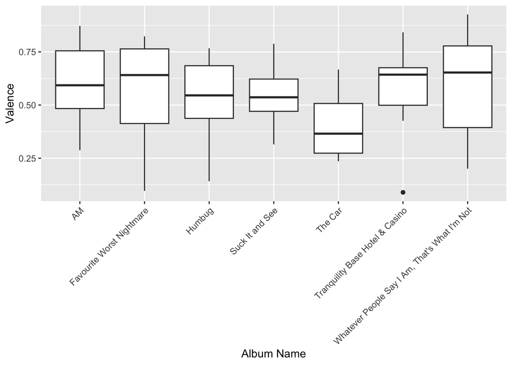

```r
library(ggplot2)

df$album_name <- as.factor(df$album_name)

# Plot a box plot with improved text formatting
ggplot(df, aes(x = album_name, y = valence)) +
  geom_boxplot() +
  labs(x = "Album Name", y = "Valence") +
  theme(axis.text.x = element_text(angle = 45, hjust = 1))  # Rotate x-axis labels
```

## Top 5 Most Energetic songs of Arctic Monkeys

```r
library(dplyr)
library(knitr)
#Top 5 most Energetic songs and display them in a table
df |>
  slice_max(energy, n = 5) |> dplyr::select(track_name, album_name, album_release_year, energy) |>
  kable(digits = 2)
```

| track_name | album_name | album_release_year | energy |
| --- | --- | --- | --- |
| Brianstorm | Favourite Worst Nightmare | 2007 | 0.97 |
| You Probably Couldn’t See For The Lights But You Were Staring Straight At Me | Whatever People Say I Am, That’s What I’m Not | 2006 | 0.97 |
| Teddy Picker | Favourite Worst Nightmare | 2007 | 0.96 |
| Fireside | AM | 2013 | 0.95 |
| The Bad Thing | Favourite Worst Nightmare | 2007 | 0.95 |

## Top 5 Saddest Songs

```r
library(dplyr)
library(knitr)
#Top sadest songs and display them in a table
df |>
  slice_min(valence, n = 5) |>  # Use slice_min for the lowest values of valence (saddest songs)
  dplyr::select(track_name, album_name, album_release_year, valence) |>
  kable(digits = 2)
```

| track_name | album_name | album_release_year | valence |
| --- | --- | --- | --- |
| Golden Trunks | Tranquility Base Hotel & Casino | 2018 | 0.09 |
| Only Ones Who Know | Favourite Worst Nightmare | 2007 | 0.10 |
| Pretty Visitors | Humbug | 2009 | 0.14 |
| A Certain Romance | Whatever People Say I Am, That’s What I’m Not | 2006 | 0.20 |
| The Car | The Car | 2022 | 0.24 |

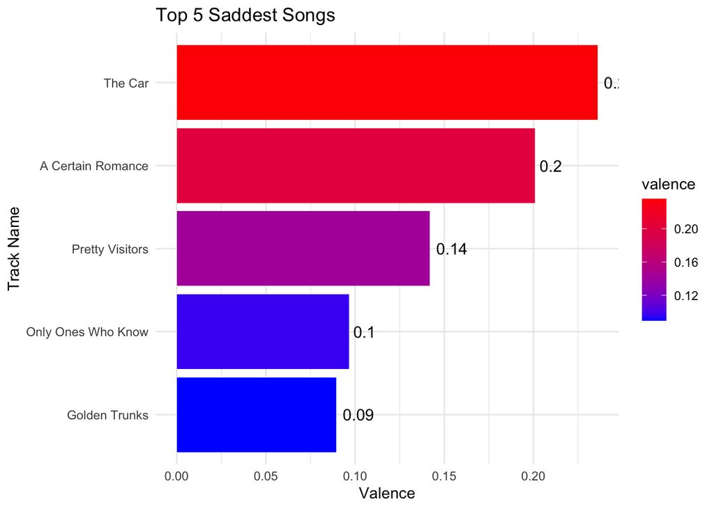

```r
library(ggplot2)

# Create the bar chart
df |>
  slice_min(valence, n = 5) |>
  ggplot(aes(x = reorder(track_name, valence), y = valence, fill = valence)) +
  geom_bar(stat = "identity") +
  geom_text(aes(label = round(valence, 2)), hjust = -0.2, size = 4) +  # Add text labels
  coord_flip() +  # Flip the coordinates for better readability
  labs(title = "Top 5 Saddest Songs", x = "Track Name", y = "Valence") +
  scale_fill_gradient(low = "blue", high = "red") +  # Color gradient for visual effect
  theme_minimal()  # Use a clean theme
```

## **Scatter plot of Arctic Monkey Songs**

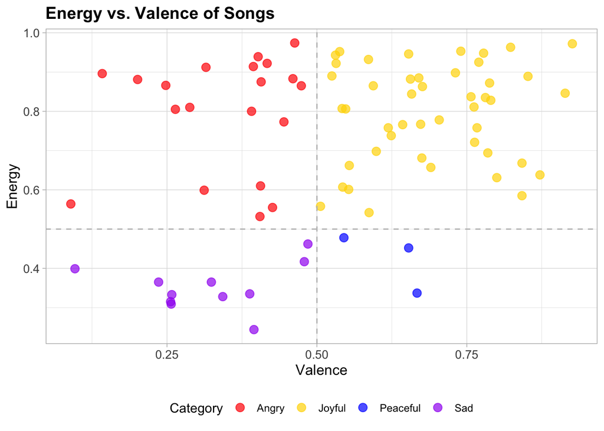

```r
library(ggplot2)
library(dplyr)

# Assuming df is your data frame with columns valence, energy, and album_name
df <- df |>
  mutate(category = case_when(
    valence >= 0.5 & energy >= 0.5 ~ "Joyful",
    valence < 0.5 & energy >= 0.5 ~ "Angry",
    valence >= 0.5 & energy < 0.5 ~ "Peaceful",
    TRUE ~ "Sad"
  ))

# Define colors for categories
category_colors <- c("Joyful" = "gold", "Angry" = "red", "Peaceful" = "blue", "Sad" = "purple")

# Plotting the scatter plot with categories
ggplot(df, aes(x = valence, y = energy, color = category)) +
  geom_point(size = 3, alpha = 0.7) +  # Adjust point size and transparency for clarity
  geom_hline(yintercept = 0.5, color = "grey", linetype = "dashed") +  # Horizontal separator
  geom_vline(xintercept = 0.5, color = "grey", linetype = "dashed") +  # Vertical separator
  scale_color_manual(values = category_colors) +  # Custom category colors
  labs(title = "Energy vs. Valence of Songs",
       x = "Valence",
       y = "Energy",
       color = "Category") +
  theme_light() +  # Cleaner theme
  theme(legend.position = "bottom",
        axis.title = element_text(size = 12),
        axis.text = element_text(size = 10),
        plot.title = element_text(size = 14, face = "bold"))
```

The data shows that Arctic Monkeys have sung most of their songs in an Angry or Joyful tone. With Joyful songs taking an edge over their Angry tone songs!

### **A Band That Keeps Moving**

From **garage rockers** to **rock gods** to **experimental musicians**, Arctic Monkeys have never stood still. Their journey is marked by **bold reinventions, sonic risks, and a refusal to be boxed into one sound**.